# Shiny App for calculating annualized returns

26/09/2019

## What does the application do?

- The application presents a plot of the DAX and FTSE indices vs time
- The user can select an area of interest in the plot
- The application will calculate the annualized returns for the indices in the selected area and report them back
- The application will plot fits through the data using the calculated annualized returns

## Example

This figure shows a fit for the period 1996.877 - 1998.415 with the following annualized returns: DAX=48.6% and FTSE=30.8%

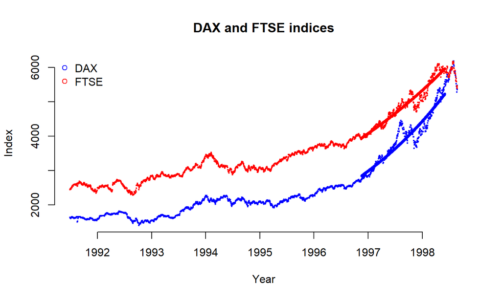

## Some technical stuff

To determine the annualized returns of the indices, the indices are modeled in the following way:

`index = a * ( 1 + R )^t`

where `a` is some constant, `R` the annualized return as a fraction and `t` is time in years.

The annualized returns `R` were estimated by fitting `log(index)` vs `t` using a linear model.

The slope of the fit equals `log(1+R)` from which `R` can be determined.

## Thank you for your attention

The application can be found by following this link: https://tsuyoshi-matsuura.shinyapps.io/InteractiveGraphics

I hope you enjoy playing with the application!!!!!